# fasteR

Hyeongchan Bae

June 2022

# Day 1

**R과 통계분석 (Tidyverse 활용) p.4~60**

## 1. Download

**R** 프로그래밍 언어. 제일 먼저 설치

- https://cran.r-project.org/bin/windows/base

**RStudio** R을 활용하기 위한 통합개발환경(IDE, Integrated Development Environment)

- 달리 말하면 RStudio 외에도 다양한 프로그램에서 R을 사용할 수 있음. 여러 언어를 사용하는 개발자는 VS Code 같은 단일 IDE를 활용하기도.
- https://www.rstudio.com/products/rstudio/download

**Rtools** 패키지를 설치하다 보면 필요한 경우(Compile)가 더러 있음

- https://cran.r-project.org/bin/windows/Rtools

**Chrome Browser** Selenium 파트에서 사용할 예정

- https://www.google.com/intl/ko_kr/chrome

**Extra Files** 인턴의 깃허브 페이지. 강의 노트, 작성 코드 등 추가적인 파일을 업로드 해둠

- https://github.com/Rlearnchan/fasteR (강의 관련)
- https://github.com/Rlearnchan/KIET_Public (업무 관련)
- Download zip 기능을 쓰거나, R 파일을 열어 코드만 체크하는 식으로 이용.
- html 버전 교재는 중요 부분에 밑줄, 긴 코드도 잘림없이 표시되니 pdf 버전과 함께 보길 권장.

## 2. Something to Know

### 1) “모두 다 같은 아마추어야”

- 익숙지 않고, 오래 걸리는 게 당연해요.
- 모든 과정을 R로 수행할 필요는 없으니, 잘 안 되면 데이터를 엑셀, STATA 등으로 옮겨 처리해오셔도 좋습니다.
- 인턴도 R이 익숙해지면서, 여러 프로그램에 걸쳐있던 작업을 하나씩 구현해보잔 마인드로 배우고 있습니다.

### 2) R 파일(확장자)

**.R** 작성한 코드

- 좌상단 Script에서 코드 작성 $\to$ 필요한 부분 실행 $\to$ 좌하단 Console 창에서 실행 결과를 확인하는 게 일반적이라, 작업 첫 파트를 저장한 것이라 볼 수 있음.
- 코드를 적은 메모장쯤 되니, **비슷한 환경**이라면 타인에게 받은 코드를 실행하기만 해도 같은 결과를 시현함.
- 동일한 패키지 설치, 중간 작업물(.Rdata, .Rhistroy) 보유 등이 **비슷한 환경**을 만듦.

**.Rdata** 작업공간 이미지

- 우상단 Environment에 기록된, 작업하며 생성된 객체, 함수, 기타 데이터들의 총체.
- 임시로 만든, 코드 실행과 무관한 object 들도 저장.

**.Rhistory** 작업 기록

- RStudio를 종료했다가, 다시 실행하면 이전 작업 상태가 비교적 온전히 남아있는데, 이를 위한 파일이라 하겠음.

**.Rmd** 마크다운 파일

- html, pdf, word 등을 만들기 위해 Markdown 문법으로 작성한, 코드 친구쯤 되는 녀석.
- 본 문서도 마크다운으로 작성. 소위 ‘R로 논문 쓴다’ 할 때 등장. tex 문법 지원.

### 3) 한글에 유독 취약한 R

**UTF-8** 인코딩 방식을 변경해주세요.

- Tools $\to$ Global Options $\to$ Code $\to$ Saving 경로.
- 타인에게 받은, 혹은 건네준 코드 파일에서 한글이 깨져 보인다면 대체로 이 문제.
- File $\to$ Reopen with Encoding 기능을 활용해 대처하는 방법도 있음.

**Library Path** 패키지 설치 경로에 한글 네이밍이 없도록 해주세요.

```r
.libPaths() # 첫 번째가 default. 개인 폴더가 설정돼 두 개 나오기도 한다.
```

```
## [1] "C:/Program Files/R/R-4.2.0/library"
```

- (윈도우 기준 예시) 만일 [2] “C:/Users/**사용자 이름**/Documents/R/win-library/4.2.0” 경로에 한글이 포함된다면, 패키지를 다룰 때마다 오류 사인을 접할 공산이 큼.
- 새로 계정을 만들지 않는 이상, **사용자 이름** 구간 폴더 명은 변경하기도 어려움.
- 다음과 같이 **사용자 이름**이 없는 기본(공용) 라이브러리를 default로 설정하길 권장.

```r
Sys.setenv('R_LIBS_USER' = 'C:/Program Files/R/R-4.2.0/library')
# R의 '개인' 세팅을 앞서 발견한 '기본(공용)' 경로로 덮어쓰기.

.libPaths('R_LIBS_USER') # 바뀐 '개인 라이브러리'를 패키지 설치 경로로 설정.
```

```r
.libPaths() # 하나의 경로로 잘 세팅되고,
```

```
## [1] "C:/Program Files/R/R-4.2.0/library"
```

```r
.libPaths() == Sys.getenv('R_LIBS_USER') # 개인 라이브러리 경로와도 일치
```

```
## [1] TRUE
```

### 4) ?, ?? 사용법

**?** 모르는 함수 검색하기

```r
?print
```

- 대부분의 함수는 R Documentation 이라 해서 정의와 기능, 인자, 간단한 사용 예시 등을 요약해둔 페이지를 가지고 있음.
- 예컨대 `print()` 함수를 자세히 알고 싶다면, 위에서 처럼 `?` 하나 붙여서 실행하면 됨.

**??** 모르는 개념, 워딩 검색하기

```r
??print
```

- 하지만 함수 이름조차 모르거나, 기능을 연상할 키워드 정도만 간신히 아는 경우도 많음.
- `??`는 모든 R Documentation 에서 해당 단어가 포함된 것을 모두 골라 보여줌.
- 두 가지를 적절히 섞어 사용하는 게 좋음.

### 5) 구글링

- 사실 구글은 모든 걸 알고 있음.
- `str_dectect()` 식으로 함수 이름 자체를 검색하면 국내외 사용자들이 포스팅한 글을 찾아보기 편함.
- `warning` 혹은 `error` 사인은 해당 문구를 적당히 복사해 구글에 그대로 쳐보는 게 좋음.
- stackoverflow 같은 개발자 커뮤니티 게시물이 주로 나올 텐데, 같은 문제로 고민한 사람들이 꽤 많았기 때문.

## 3. Basic Function

### 1) 숫자 계산

```r
3+4-7/3 # 달리 명령어가 필요하진 않으나,
```

```
## [1] 4.666667
```

```r
print(3+4-7/3) # print() 함수를 사용할 수도 있음
```

```
## [1] 4.666667
```

```r
print(3+4-7/3, digits = 3) # 세 번째 자리에서 반올림
```

```
## [1] 4.67
```

- `print()` 함수엔 `digits` 라는 인자(설정 옵션)가 있음.

```r
rnorm(n = 5, mean = 0, sd = 1) # n(0, 1) 분포에서 5개 난수 생성
```

```
## [1]  1.9990701 -2.0369602  0.1503897  1.3337924  0.5777084
```

```r
stats::rnorm(n = 5, mean = 0, sd = 1) # stats 패키지의 rnorm() 함수
```

```
## [1]  1.26578062 -0.31812782  0.91527111 -0.46061779 -0.07918369
```

- 기본 패키지, 혹은 `library()` 로 장착한 패키지의 함수는 `::` 표기를 사용하지 않아도 됨.
- 여러 패키지를 동시에 사용하는 경우, 유사한 이름의 함수 간 혼동을 피하기 위해 `::` 방식을 사용하기도 함.

```r
set.seed(seed = 10)
```

- reproducibility 위해서 난수 생성 규칙을 `set.seed()`로 부여.
- model 성능을 보려 같은 숫자를 input할 경우나, 지금처럼 같은 결과물을 공유할 때.

```r
rnorm(5, 0, 1)
```

```
## [1]  0.01874617 -0.18425254 -1.37133055 -0.59916772  0.29454513
```

### 2) 텍스트

```r
'banana' # 작은 따옴표
```

```
## [1] "banana"
```

```r
"banana" # 큰 따옴표 모두 사용 가능
```

```
## [1] "banana"
```

```r
class('banana') # 문자 클래스
```

```
## [1] "character"
```

- 그냥 `banana`라고 치면 `banana` 이름을 가진 객체, 그 속의 값을 호출하란 명령.
- 해당 객체가 부재해서, R과 내가 그런 약속을 한 바 없으므로 에러가 발생할 것.
- `class()` 함수는 자주 쓰니 기억해 둘 필요가 있음.
- 함수는 인자마다 특정 클래스를 요구하곤 함.
- 예컨대 숫자(double) 자리인데, 텍스트(string)을 입력한다든지. 매우 흔한 오류 케이스.

```r
paste0('이제와', '뒤늦게', '무엇을 더 보태려하나') # 문자열 붙여서 하나로 만듦
```

```
## [1] "이제와뒤늦게무엇을 더 보태려하나"
```

```r
paste0('이제와 ', '뒤늦게 ', '무엇을 더 보태려하나') # 띄어쓰기를 추가해보자
```

```
## [1] "이제와 뒤늦게 무엇을 더 보태려하나"
```

- 띄어쓰기를 포함한 문구를 `paste0()` 함수로 잇는 게 직관적이면서 유용.

```r
paste('이제와', '뒤늦게', '무엇을 더 보태려하나') # 한 칸씩 띄어쓰는 게 default인 함수
```

```
## [1] "이제와 뒤늦게 무엇을 더 보태려하나"
```

```r
paste('이제와', '뒤늦게', '무엇을 더 보태려하나', sep = '둠칫') # 사실 sep = ' ' 인자가 숨어있던 것. 바꿀 수도 있음.
```

```
## [1] "이제와둠칫뒤늦게둠칫무엇을 더 보태려하나"
```

### 3) 객체

```r
BR31 = 'Alien Mom' # 텍스트를 BR31 객체에 저장

br31 = 'Mint Choco' # 텍스트를 br31 객체에 저장
```

```r
BR31
```

```
## [1] "Alien Mom"
```

```r
br31
```

```
## [1] "Mint Choco"
```

- ‘너 `BR31` 뭔지 알지? 우리 약속했잖아…’

```r
paste('Which do you prefer', BR31, 'or', br31) # 객체명을 입력하면 담긴 것을 가져다 씀.
```

```
## [1] "Which do you prefer Alien Mom or Mint Choco"
```

- 객체 명을 지을 땐 **대소문자 구별**, 그리고 **첫 글자엔 숫자 및 기호 불가** 특성을 고려해야 함.
- 괄호나 슬래시처럼 함수 구성, 연산에 쓰일 법한 기호는 특히 오류가 빈번.

### 4) 벡터

```r
Yunha = c(4, 8, 6) # 숫자 세 개를 벡터로 묶어 저장
```

```r
Yunha
```

```
## [1] 4 8 6
```

```r
class(Yunha) # 숫자 속성이 그대로 남아 있음
```

```
## [1] "numeric"
```

```r
Yunha = c('Password', 4, 8, 6) # 원소가 하나라도 character가 섞이면
```

```r
Yunha # 따옴표 찍힌 것부터 느낌이 다르고,
```

```
## [1] "Password" "4"        "8"        "6"
```

```r
class(Yunha) # 얄짤없이 전부 character로 저장
```

```
## [1] "character"
```

### 5) 행렬

```r
matrix(data = c(1, 2, 3, 4, 5, 6, 7, 8, 9, 10, 11, 12), nrow = 3, ncol = 4)
```

```
##      [,1] [,2] [,3] [,4]
## [1,]    1    4    7   10
## [2,]    2    5    8   11
## [3,]    3    6    9   12
```

- `data = what` 해야되는데, `data = 1, 2, 3, ...` 식으로는 정확한 제시가 안 됨.
- R은 `data = 1` 이고, `2, 3, ...`은 `matrix()` 함수의 다른 input 쯤으로 인식.
- 따라서 `1, 2, 3, ...`을 묶어줘야 하고, 여기선 vector를 쓴 것.

```r
matrix(data = c(1, 2, 3, 4, 5, 6, 7, 8, 9, 10, 11, 12), nrow = 3, ncol = 4, dimnames = list(c('가', '나', '다'), c('A', 'B', 'C', 'D'))) # 행이름, 열이름 설정
```

```
##    A B C  D
## 가 1 4 7 10
## 나 2 5 8 11
## 다 3 6 9 12
```

- 마찬가지로 `dimnames = what` 위해서, 벡터 두 개를 상위 개념인 list로 묶음.
- `scala`, `vector`, `matrix(or dataframe)`, …, `list`
- `요거트`, `요거트 4개 묶음`, `플레인 4개 + 딸기맛 4개 세일상품`, …, `장바구니`
- list 아래는 이것저것 다 들어감. 다른 list도 원소로 가질 수 있음.

```r
matrix(data = c(1, 2, 3, 4, 5, 6, 7, 8, 9, 10, 11, 12),
       dimnames = list(c('가', '나', '다'), c('A', 'B', 'C', 'D')),
       nrow = 3, ncol = 4) # 엔터를 적극 활용.
```

```
##    A B C  D
## 가 1 4 7 10
## 나 2 5 8 11
## 다 3 6 9 12
```

- 마지막 코드에선 인자들의 순서가 조금 다른데, 이는 인자명을 지정해줬기 때문에 가능한 것.
- 지정만 잘 돼있으면 섞여도 상관 없음.
- 코드가 길어지면 한 번에 보기 어려우니, 적당한 단위마다 엔터를 쳐주자.

```r
mat <- matrix(1:12, 3, 4) # matrix() 함수의 처음 세 인자가 data, nrow, ncol 이므로 필요한 값만 입력.

colnames(mat) <- c('A', 'B', 'C', 'D') # 열이름 덮어쓰기

rownames(mat) <- c('가', '나', '다') # 행이름 덮어쓰기
```

- `1:12`는 `seq(from = 1, to = 12, by = 1)` 과 같음.
- `<-`는 `=`과 같음.
- 자주쓰는 함수라면 인자들 위치를 대개 아니까, input 값만 순서에 맞춰 넣어도 좋다.
- 다만, 타인과 공유할 때, 혹은 미래의 내가 볼 땐 다소 헷갈릴 수도.
- 코드를 가장 잘 아는 건 코드 쓸 때의 나 자신.
- 같은 작업이라도 여러 route가 있음.

```r
mat
```

```
##    A B C  D
## 가 1 4 7 10
## 나 2 5 8 11
## 다 3 6 9 12
```

```r
class(mat)
```

```
## [1] "matrix" "array"
```

### 6) 데이터프레임

```r
윤하 <- as.data.frame(Yunha)

matthew <- as.data.frame(mat)
```

- `as.data.frame()` 함수는 벡터, 행렬 등을 인자로 받음.

```r
윤하
```

```
##      Yunha
## 1 Password
## 2        4
## 3        8
## 4        6
```

```r
class(윤하)
```

```
## [1] "data.frame"
```

- 데이터프레임은 row = observation, column = variable 개념이라, 열 이름을 웬만하면 채우려고 하는데, 여기선 character vector 이름인 Yunha를 차용한 모습.
- 벡터 이름 : 벡터 내용 = 변수 이름 : 관측치 느낌으로 해석한 듯.

```r
matthew
```

```
##    A B C  D
## 가 1 4 7 10
## 나 2 5 8 11
## 다 3 6 9 12
```

```r
class(matthew)
```

```
## [1] "data.frame"
```

- 경제, 통계에서 다루는 데이터는 대개 2차원 + 변수 이름 확실 + observation 여러 개인 형태.
- R은 데이터프레임 형태를 기본으로 두고 있으며, Python에선 이를 구현하기 위해 `pandas` 라이브러리가 존재.
- `pandas`는 panel data analysis의 약자. 물론 마스코트는 팬더.

### 7) 인덱싱

```r
Yunha[2] # Yunha 벡터의 두 번째 요소
```

```
## [1] "4"
```

```r
mat[, 1] # mat 행렬의 첫 열
```

```
## 가 나 다
##  1  2  3
```

```r
mat[2, 2] # mat 행렬의 (2, 2) 요소
```

```
## [1] 5
```

```r
matthew$A # matthew 데이터프레임의 변수 A에 속한 값
```

```
## [1] 1 2 3
```

- `dataframe $ variable` 인덱싱은 정말 자주 사용.
- 하나의 열벡터로 추출하는 거라, `matthew$A[3]` 식으로 다시 한 번 인덱싱 가능.

```r
matthew[2, 2] # matthew 데이터프레임의 (2, 2) 요소
```

```
## [1] 5
```

- 데이터프레임의 인덱싱이 조금 더 깔끔한 느낌.
- 실제 작업에도 용이한바, R의 데이터분석은 대개 데이터프레임 형태를 사용.

## 4. Others

**#** 주석처리

- 코드 설명 작성 : `print(a) # a를 출력한다`
- 해당 부분을 실행에서 제외 : `#print(a)`

**업데이트** R, RStudio 모두 꾸준히 새 버전이 나오지만, 구 버전을 사용해도 큰 문제 없음

- R은 새로 설치하고 구 버전을 삭제하는 게 제일 간편. RStudio는 알아서 최근 설치한 R을 인식해 사용.
- RStudio는 Help $\to$ Check for Updates 기능을 활용.
- 패키지는 Tools $\to$ Check for Package Updates

**Working Directory** 작업 공간(폴더)을 지정하자

- 외부 파일을 불러오거나, 외부로 저장할 일이 많음.
- R은 기본적으로 `C:/Users/Document`, 즉 내 문서 폴더를 기본 작업 공간으로 인식.
- 매번 내 문서 폴더에서 작업을 할 순 없는 노릇.
- `setwd(folder)` 함수의 folder 인자에 원하는 경로를 입력.

```r
setwd('C:\Users\KIET\Documents\GitHub') # 그대로 붙여넣으면 안 되고,

setwd('C:/Users/KIET/Documents/GitHub') # \를 /로 교체해줘야 함.
```

- R에서 `\` 문자는 정규표현식의 하나로, 슬래시 표현 외에 약속된 다른 기능을 담당함.
- 그런 차에 `/`를 경로 기술에 대신 사용하는 듯.

## 5. Quiz

**초급** 다음의 행렬을 만들어보자

```
##         var1 var2 var3
## Case #1   12   21   32
## Case #2   17   22   34
## Case #3   19   25   35
```

**중급** `datasets::iris` 데이터를 가져와 다음을 해결해보자

1. `iris` 변수의 이름을 `names()` 함수로 확인하라.
2. `iris` 관찰값, 변수의 개수를 `dim()`, `nrow()`, `length()` 함수로 확인하라.
3. `iris` 처음 세 줄과 마지막 세 줄을 `head()`, `tail()` 함수로 출력하라.
4. `iris` 데이터를 간단히 소개하라.

**고급** 다음 코드의 문제점을 지적해보자. 수정본을 참고해도 좋다.

```r
I-DLE_MEMBERS <- c('소연', '미연', '민니', '우기', '슈화')

I-DLE_LYLICS <- c('Look at you 넌 못 감당해 날',
                  'I got to drink up now 네가 싫다 해도 좋아',
                  'Why are you cranky, boy? 뭘 그리 찡그려 너',
                  '미친 연이라 말해 What's the loss to me ya',
                  '사랑 그깟 거 따위 내 몸에 상처 하나도 어림없지',
                  'Ye I'm a Tomboy (Umm ah umm)',
                  'Ye I'll be the Tomboy (Umm ah)')

TOMBOY <- data.frame(I-DLE_MEMBERS, I-DLE_LYLICS)
```

```
## Error: <text>:7:35: 예상하지 못한 기호(symbol)입니다.
## 6:                   'Why are you cranky, boy? 뭘 그리 찡그려 너',
## 7:                   '미친 연이라 말해 What's
##                                      ^
```

```r
IDLE_MEMBERS <- c('소연', '미연', '민니', '우기', '슈화')

IDLE_LYLICS <- c('Look at you 넌 못 감당해 날',
                 'I got to drink up now 네가 싫다 해도 좋아',
                 'Why are you cranky, boy? 뭘 그리 찡그려 너',
                 "미친 연이라 말해 What's the loss to me ya",
                 '사랑 그깟 거 따위 내 몸에 상처 하나도 어림없지',
                 "Ye I'm a Tomboy (Umm ah umm)",
                 "Ye I'll be the Tomboy (Umm ah)")

TOMBOY <- data.frame(MEMBERS = IDLE_MEMBERS[c(3, 4, 1, 2, 4, 3, 5)],
                     LYLICS = IDLE_LYLICS)

TOMBOY
```

```
##   MEMBERS                                         LYLICS
## 1    민니                    Look at you 넌 못 감당해 날
## 2    우기      I got to drink up now 네가 싫다 해도 좋아
## 3    소연     Why are you cranky, boy? 뭘 그리 찡그려 너
## 4    미연      미친 연이라 말해 What's the loss to me ya
## 5    우기 사랑 그깟 거 따위 내 몸에 상처 하나도 어림없지
## 6    민니                   Ye I'm a Tomboy (Umm ah umm)
## 7    슈화                 Ye I'll be the Tomboy (Umm ah)
```

# Day 2

**R과 통계분석 (Tidyverse 활용) p.102~146**

**파이썬 머신러닝 판다스 데이터 분석 p.2~55**

## 1. What is Tidyverse

**Package for Packages** 데이터 분석을 위한 패키지의 모음집

- https://www.tidyverse.org/packages/
- `Tidyverse` 생태계라 봐도 괜찮음.

```r
install.packages('tidyverse') # library() 와는 달리 따옴표를 붙여줘야 함, 이하에선 인스톨 생략
```

```r
library(tidyverse) # tidyverse 패키지 장착
```

**And then, and then** 직관적인 연결 작업

- tidyverse 계열 함수들은 첫 번째 입력값을 data로 통일. `function(data, actions)` 개념.
- pipe operator `%>%`는 앞선 작업 결과물을 다음 함수의 첫 요소로 대입하는 기능
- `x %>% f(y)` $\to$ `f(x, y)` 식으로 결합 사용하는 게 일반적.

**Key Setting** 두 가지 단축키 설정 권장

- Tools $\to$ Modify Keyboard Shortcuts 에서 단축키를 확인, 변경할 수 있음.
- 가장 자주 쓰는 `<-`, `%>%` 정도는 단축키를 활용하는 게 좋음.
- 인턴은 `Insert Assign Operator`를 `home`, `Insert Pipe Operator`를 `end`에 두고 사용.

## 2. Exercise : PSI 보도자료

**2022년 2월 PSI** https://www.kiet.re.kr/kiet_web/?sub_num=1503&state=view&idx=59127&ord=0

### 1) 데이터 로드

```r
library(openxlsx) # openxlsx 패키지 장착

read.xlsx('PSI 연습용.xlsx')
```

```
##    연도 월              구분 응답수  경기현황  경기전망 시장판매현황
## 1  2022  2           00_전체    235  96.17021 110.63830    102.55319
## 2  2022  2            01_ICT     86  94.18605 110.46512    100.00000
## 3  2022  2           02_장비     76 102.63158 110.52632    107.89474
## 4  2022  2           03_소재     52  82.69231 111.53846     92.30769
## 5  2022  2           04_전자     42 109.52381 135.71429    109.52381
## 6  2022  2           05_가전     16 106.25000 143.75000    100.00000
## 7  2022  2         06_핸드폰     26 111.53846 130.76923    115.38462
## 8  2022  2     07_디스플레이     21  85.71429  90.47619     76.19048
## 9  2022  2         08_반도체     23  73.91304  82.60870    104.34783
## 10 2022  2           09_기계     22 100.00000 100.00000    100.00000
## 11 2022  2         10_자동차     34 102.94118 120.58824    114.70588
## 12 2022  2           11_조선     20 105.00000 105.00000    105.00000
## 13 2022  2           12_섬유     16  75.00000 112.50000     81.25000
## 14 2022  2           13_철강     14 100.00000 121.42857    100.00000
```

[output cut: 73 more lines]

- `setwd()` 함수로 작업 경로를 지정했고, 해당 폴더 내 excel 파일이 있음을 전제.

```r
PSI_ORIGINAL <- read.xlsx('PSI 연습용.xlsx') %>%
  tibble() # 엑셀 파일을 읽어서 PSI_ORIGINAL 이라 명명.

PSI_ORIGINAL # tibble을 사용하니, 직전보단 깔끔하게 저장된다. class 표시는 덤.
```

```
## # A tibble: 21 × 20
##     연도    월 구분  응답수 경기현황 경기전망 시장판매현황 시장판매전망 수출현황
##    <dbl> <dbl> <chr>  <dbl>    <dbl>    <dbl>        <dbl>        <dbl>    <dbl>
##  1  2022     2 00_…     235     96.2    111.         103.         114.     106.
##  2  2022     2 01_I…     86     94.2    110.         100          113.     110.
##  3  2022     2 02_…      76    103.     111.         108.         113.     118.
##  4  2022     2 03_…      52     82.7    112.          92.3        121.      82.7
##  5  2022     2 04_…      42    110.     136.         110.         129.     133.
##  6  2022     2 05_…      16    106.     144.         100          119.     112.
##  7  2022     2 06_…      26    112.     131.         115.         135.     146.
##  8  2022     2 07_…      21     85.7     90.5         76.2         90.5     81.0
##  9  2022     2 08_…      23     73.9     82.6        104.         104.      95.7
## 10  2022     2 09_…      22    100      100          100          100      114.
## # … with 11 more rows, and 11 more variables: 수출전망 <dbl>,
## #   생산수준현황 <dbl>, 생산수준전망 <dbl>, 재고수준현황 <dbl>,
## #   재고수준전망 <dbl>, 신규수주현황 <dbl>, 신규수주전망 <dbl>,
## #   투자액현황 <dbl>, 투자액전망 <dbl>, 채산성현황 <dbl>, 채산성전망 <dbl>
```

- `read.xlsx()` 함수의 첫 인자는 `xlsxFile` 으로, 해당 파일의 경로를 입력해야 함.
- 정확한 경로와 이름을 적으면서, 확장자 명을 꼭 포함할 것.
- 두 번째 인자는 `sheetName`, 미지정 시 첫 번째 시트를 로드한다. 다중 시트로 이뤄진 엑셀 파일이라면 시트 이름을 지정해주는 게 유용.
- 데이터 프레임을 가져올 땐 `tibble()` 함수를 거쳐서 단정하게 만들자.
- 여담으로 `xlsxFile`, `sheetName` 처럼 영문 가운데 capital을 섞어주는 걸 camel 표기법이라 함.

### 2) 훑어보기

```r
PSI_ORIGINAL %>% head() # 상위 순번 관측값만 표시, default = 6개
```

```
## # A tibble: 6 × 20
##    연도    월 구분   응답수 경기현황 경기전망 시장판매현황 시장판매전망 수출현황
##   <dbl> <dbl> <chr>   <dbl>    <dbl>    <dbl>        <dbl>        <dbl>    <dbl>
## 1  2022     2 00_전…    235     96.2     111.        103.          114.    106.
## 2  2022     2 01_ICT     86     94.2     110.        100           113.    110.
## 3  2022     2 02_장…     76    103.      111.        108.          113.    118.
## 4  2022     2 03_소…     52     82.7     112.         92.3         121.     82.7
## 5  2022     2 04_전…     42    110.      136.        110.          129.    133.
## 6  2022     2 05_가…     16    106.      144.        100           119.    112.
## # … with 11 more variables: 수출전망 <dbl>, 생산수준현황 <dbl>,
## #   생산수준전망 <dbl>, 재고수준현황 <dbl>, 재고수준전망 <dbl>,
## #   신규수주현황 <dbl>, 신규수주전망 <dbl>, 투자액현황 <dbl>, 투자액전망 <dbl>,
## #   채산성현황 <dbl>, 채산성전망 <dbl>
```

- `head(n = 10)` 해서 상위 10개를 볼 수도 있음.
- tidyverse 함수가 아녀도 pipe operator를 사용할 수 있음. 시너지가 좋은 거지, 개별로도 powerful.

```r
PSI_ORIGINAL %>% names() # 변수 이름
```

```
##  [1] "연도"         "월"           "구분"         "응답수"       "경기현황"
##  [6] "경기전망"     "시장판매현황" "시장판매전망" "수출현황"     "수출전망"
## [11] "생산수준현황" "생산수준전망" "재고수준현황" "재고수준전망" "신규수주현황"
## [16] "신규수주전망" "투자액현황"   "투자액전망"   "채산성현황"   "채산성전망"
```

```r
PSI_ORIGINAL %>% dim() # dimension
```

```
## [1] 21 20
```

```r
PSI_ORIGINAL$구분 # 데이터 '구분' 열에 담긴 관측값들
```

```
##  [1] "00_전체"           "01_ICT"            "02_장비"
##  [4] "03_소재"           "04_전자"           "05_가전"
##  [7] "06_핸드폰"         "07_디스플레이"     "08_반도체"
## [10] "09_기계"           "10_자동차"         "11_조선"
## [13] "12_섬유"           "13_철강"           "14_화학"
## [16] "15_바이오헬스"     "16_애널리스트"     "17_공공기관및기타"
## [19] "18_애널리스트"     "19_공공기관"       "20_기타"
```

```r
PSI_ORIGINAL[2, ] # 데이터 2열 관측값
```

```
## # A tibble: 1 × 20
##    연도    월 구분   응답수 경기현황 경기전망 시장판매현황 시장판매전망 수출현황
##   <dbl> <dbl> <chr>   <dbl>    <dbl>    <dbl>        <dbl>        <dbl>    <dbl>
## 1  2022     2 01_ICT     86     94.2     110.          100         113.     110.
## # … with 11 more variables: 수출전망 <dbl>, 생산수준현황 <dbl>,
## #   생산수준전망 <dbl>, 재고수준현황 <dbl>, 재고수준전망 <dbl>,
## #   신규수주현황 <dbl>, 신규수주전망 <dbl>, 투자액현황 <dbl>, 투자액전망 <dbl>,
## #   채산성현황 <dbl>, 채산성전망 <dbl>
```

### 3) 응답자 비율 구하기

```r
PSI_ORIGINAL %>% # 원본 데이터에서
  select(구분, 응답수) %>% # 구분, 응답수 열을 고른 다음
  mutate(비율 = 응답수/235*100) # 새로운 열을 추가하는데, 얘는 응답수/235*100 계산값임.
```

```
## # A tibble: 21 × 3
##    구분          응답수   비율
##    <chr>          <dbl>  <dbl>
##  1 00_전체          235 100
##  2 01_ICT            86  36.6
##  3 02_장비           76  32.3
##  4 03_소재           52  22.1
##  5 04_전자           42  17.9
##  6 05_가전           16   6.81
##  7 06_핸드폰         26  11.1
##  8 07_디스플레이     21   8.94
##  9 08_반도체         23   9.79
## 10 09_기계           22   9.36
## # … with 11 more rows
```

- `select(data_table, columns, ... )` 원하는 column 고르기. 위치 인덱스나 변수 명을 적으면 됨.
- `select(-1)` 식으로 쓰면, 첫 번째 열을 제외하고 모두 선택.
- `mutate(data_table, var_name = new_data, ...)` 새로운 열 만들기(덮어쓰기 가능).
- 인턴의 함수 설명이, 실제 인자값 네이밍을 적은 건 아님에 유의. 뉘앙스로 이해.

```r
PSI_RATE.1 <- PSI_ORIGINAL %>%
  select(구분, 응답수) %>%
  mutate(비율 = 응답수/235*100) # 앞서 만든 데이터를 하나의 객체로 저장해두자.

PSI_RATE.2 <- PSI_RATE.1 %>% # 아까 하던 거에서
  mutate(비율 = round(비율, digits = 1)) %>% # 비율 값은 반올림해서 덮어씌우고
  slice(1:18) # 필요한 row만 선택하자.
```

- 객체를 나누면, 작업 과정을 분기할 수 있음. 일종의 save point.

```r
PSI_RATE.2 # 좋긴 한데, 보도자료는 업종 순서가 달라서 붙여넣기가 애매.
```

```
## # A tibble: 18 × 3
##    구분              응답수  비율
##    <chr>              <dbl> <dbl>
##  1 00_전체              235 100
##  2 01_ICT                86  36.6
##  3 02_장비               76  32.3
##  4 03_소재               52  22.1
##  5 04_전자               42  17.9
##  6 05_가전               16   6.8
##  7 06_핸드폰             26  11.1
##  8 07_디스플레이         21   8.9
##  9 08_반도체             23   9.8
## 10 09_기계               22   9.4
## 11 10_자동차             34  14.5
## 12 11_조선               20   8.5
## 13 12_섬유               16   6.8
## 14 13_철강               14   6
## 15 14_화학               22   9.4
## 16 15_바이오헬스         21   8.9
## 17 16_애널리스트        105  44.7
## 18 17_공공기관및기타    130  55.3
```

- `slice(data_table, rows, ...)` 원하는 row 고르기.

```r
PSI_RATE.2[c(2, 3, 4, 9, 8, 5, 7, 6, 11, 12, 10, 15, 14, 13, 16, 17, 18), ] # 순서를 바꾸면 되지
```

```
## # A tibble: 17 × 3
##    구분              응답수  비율
##    <chr>              <dbl> <dbl>
##  1 01_ICT                86  36.6
##  2 02_장비               76  32.3
##  3 03_소재               52  22.1
##  4 08_반도체             23   9.8
##  5 07_디스플레이         21   8.9
##  6 04_전자               42  17.9
##  7 06_핸드폰             26  11.1
##  8 05_가전               16   6.8
##  9 10_자동차             34  14.5
## 10 11_조선               20   8.5
## 11 09_기계               22   9.4
## 12 14_화학               22   9.4
## 13 13_철강               14   6
## 14 12_섬유               16   6.8
## 15 15_바이오헬스         21   8.9
## 16 16_애널리스트        105  44.7
## 17 17_공공기관및기타    130  55.3
```

```r
APPENDIX.1 <- PSI_RATE.2[c(2, 3, 4, 9, 8, 5, 7, 6, 11, 12, 10, 15, 14, 13, 17, 18), ] # 완성품 저장
```

- 완성품, 중간 작업물은 네이밍 규칙을 달리 가져가는 게 편하다.
- 객체를 왕창 만들다보면 헷갈릴 일이 생기기 마련.
- 인턴의 네이밍 규칙은 이렇다.
- 임시 : `temp1`, `temp2`, …
- 중간작업 : `대문자_파트.버전`
- 완성품은 다른 이름으로 저장.

### 4) 기상도 만들기

```r
PSI_WEATHER.1 <- PSI_ORIGINAL %>%
  select(3, '경기현황', `시장판매현황`, 수출현황,
         생산수준현황, 투자액현황, 채산성현황) # 인덱스, '변수명', `변수명`, 변수명 모두 가능

PSI_WEATHER.1
```

```
## # A tibble: 21 × 7
##    구분       경기현황 시장판매현황 수출현황 생산수준현황 투자액현황 채산성현황
##    <chr>         <dbl>        <dbl>    <dbl>        <dbl>      <dbl>      <dbl>
##  1 00_전체        96.2        103.     106.         106.       109.        86.4
##  2 01_ICT         94.2        100      110.         113.       101.        87.2
##  3 02_장비       103.         108.     118.         108.       116.        98.7
##  4 03_소재        82.7         92.3     82.7         88.5      106.        61.5
##  5 04_전자       110.         110.     133.         124.       102.       107.
##  6 05_가전       106.         100      112.         112.       100        112.
##  7 06_핸드폰     112.         115.     146.         131.       104.       104.
##  8 07_디스플…     85.7         76.2     81.0         81.0       90.5       76.2
##  9 08_반도체      73.9        104.      95.7        122.       109.        60.9
## 10 09_기계       100          100      114.          95.5       95.5       77.3
## # … with 11 more rows
```

```r
PSI_WEATHER.2 <- PSI_WEATHER.1 %>%
  mutate_at(.vars = 2:7, .funs = round) # 2:7열 관측값에 반올림 적용

PSI_WEATHER.2
```

```
## # A tibble: 21 × 7
##    구분       경기현황 시장판매현황 수출현황 생산수준현황 투자액현황 채산성현황
##    <chr>         <dbl>        <dbl>    <dbl>        <dbl>      <dbl>      <dbl>
##  1 00_전체          96          103      106          106        109         86
##  2 01_ICT           94          100      110          113        101         87
##  3 02_장비         103          108      118          108        116         99
##  4 03_소재          83           92       83           88        106         62
##  5 04_전자         110          110      133          124        102        107
##  6 05_가전         106          100      112          112        100        112
##  7 06_핸드폰       112          115      146          131        104        104
##  8 07_디스플…       86           76       81           81         90         76
##  9 08_반도체        74          104       96          122        109         61
## 10 09_기계         100          100      114           95         95         77
## # … with 11 more rows
```

- `mutate_at(data_table, .vars, .funs, ...)` 는 `mutate()`의 고급 버전.
- `.funs`에 입력한 함수를 `.vars`에 입력한 변수에 일괄 적용하고 덮어씌움.

```r
PSI_WEATHER.3 <- PSI_WEATHER.2[c(1, 9, 8, 5, 7, 6, 11, 12, 10, 15, 14, 13, 16, 2, 3, 4), ]

colnames(PSI_WEATHER.3) <- c('구분', '업황', '내수', '수출', '생산수준', '투자액', '채산성')

PSI_WEATHER.3 # 갖다 붙이려 했는데, 숫자가 묘하게 다름. 특히 가전 파트.
```

```
## # A tibble: 16 × 7
##    구분           업황  내수  수출 생산수준 투자액 채산성
##    <chr>         <dbl> <dbl> <dbl>    <dbl>  <dbl>  <dbl>
##  1 00_전체          96   103   106      106    109     86
##  2 08_반도체        74   104    96      122    109     61
##  3 07_디스플레이    86    76    81       81     90     76
##  4 04_전자         110   110   133      124    102    107
##  5 06_핸드폰       112   115   146      131    104    104
##  6 05_가전         106   100   112      112    100    112
##  7 10_자동차       103   115   121      106    132    109
##  8 11_조선         105   105   120      125    110    105
##  9 09_기계         100   100   114       95     95     77
## 10 14_화학          77    95    77      100    105     50
## 11 13_철강         100   100    86       71    129     79
## 12 12_섬유          75    81    88       88     88     62
## 13 15_바이오헬스   114   119   105      114    124    100
## 14 01_ICT           94   100   110      113    101     87
## 15 02_장비         103   108   118      108    116     99
## 16 03_소재          83    92    83       88    106     62
```

- R의 `round()` 함수는 `round(0.5) = 0` 으로 계산해버림.
- 그럼 어떻게 해야할까. 뭐 구글 가야죠.

```r
round2 = function(x, n = 0) {

  posneg = sign(x)
  z = abs(x)*10^n
  z = z + 0.5 + sqrt(.Machine$double.eps)
  z = trunc(z)
  z = z/10^n
  z*posneg

} # 구글 멋쟁이가 만들어둔 함수를 그대로 긁어오자

round(0.5) ; round2(0.5, 0) # 두 번째 인자 n은 digits
```

```
## [1] 0
```

```
## [1] 1
```

- `function(factors, ...) { what to do }` 식으로 사용자 함수를 정의할 수 있음.
- 아래 `mutate_at()` 함수에서 오류가 나서, n의 default 값만 `function(x, n = 0)` 으로 수정하자.
- tidyverse 함수에선 직전 작업 값 ‘.’ 으로 표현한다. `.$구분` 으로 적어도 해당 흐름 내에선 ‘작업 중이던 데이터프레임의 구분 열’ 쯤으로 인식하는 셈.
- `.vars`, `.funs`도 유사한 맥락의 네이밍인데, 설명하는 건 강의 레벨을 벗어나므로 스킵.
- 궁금한 사람은 `purrr` 패키지 참고.

```r
PSI_WEATHER.2 <- PSI_WEATHER.1 %>%
  mutate_at(.vars = 2:7, .funs = round2) # 반올림 함수 교체

PSI_WEATHER.3 <- PSI_WEATHER.2[c(1, 9, 8, 5, 7, 6, 11, 12, 10, 15, 14, 13, 16, 2, 3, 4), ]

colnames(PSI_WEATHER.3) <- c('구분', '업황', '내수', '수출', '생산수준', '투자액', '채산성')

PSI_WEATHER.3
```

```
## # A tibble: 16 × 7
##    구분           업황  내수  수출 생산수준 투자액 채산성
##    <chr>         <dbl> <dbl> <dbl>    <dbl>  <dbl>  <dbl>
##  1 00_전체          96   103   106      106    109     86
##  2 08_반도체        74   104    96      122    109     61
##  3 07_디스플레이    86    76    81       81     90     76
##  4 04_전자         110   110   133      124    102    107
##  5 06_핸드폰       112   115   146      131    104    104
##  6 05_가전         106   100   113      113    100    113
##  7 10_자동차       103   115   121      106    132    109
##  8 11_조선         105   105   120      125    110    105
##  9 09_기계         100   100   114       95     95     77
## 10 14_화학          77    95    77      100    105     50
## 11 13_철강         100   100    86       71    129     79
## 12 12_섬유          75    81    88       88     88     63
## 13 15_바이오헬스   114   119   105      114    124    100
## 14 01_ICT           94   100   110      113    101     87
## 15 02_장비         103   108   118      108    116     99
## 16 03_소재          83    92    83       88    106     62
```

```r
APPENDIX.2 <- PSI_WEATHER.3 # 완성품 저장
```

- `PSI_WEATER.2`, `PSI_WEATHER.3` 만드는 코드를 고치자.
- 객체명을 따로 안 바꿔서, new version 으로 덮어씌우게 됨.
- 객체 네이밍을 순차적으로 했어서, 수정할 부분을 빠르게 찾고, 해당 파트만 교체하는 게 어렵지 않다.

### 5) 엑셀 출력하기

```r
write.xlsx(x = list(APPENDIX.1, APPENDIX.2), # 완성품 두 개를
           sheetName = c('응답자 비율', '기상도'), # 각각의 시트로 갖는
           file = 'PSI 보도자료.xlsx') # 엑셀 파일 생성
```

- 작업 중인 폴더에 엑셀 파일이 생성된다.
- list 클래스는 최상위 레벨로, 앞서 다룬 벡터, 행렬, 데이터프레임 등을 원소로 가질 수 있음.
- 가끔 list를 입력 인자로 요구하는 함수가 있으니 알아두자.

## 3. Advanced : 미국 수출데이터 가공

```r
library(tidyverse)

USTRADE <- read_csv('미국수출 연습용.csv')
```

- UN Commodity Trade 자료의 일부.

```r
USTRADE # read_csv() 사용하면 tibble 형태로 저장
```

```
## # A tibble: 82,487 × 35
##    Classification  Year Period `Period Desc.` `Aggregate Level` `Is Leaf Code`
##    <chr>          <dbl>  <dbl>          <dbl>             <dbl>          <dbl>
##  1 H5              2020   2020           2020                 6              1
##  2 H5              2020   2020           2020                 6              1
##  3 H5              2020   2020           2020                 6              1
##  4 H5              2020   2020           2020                 6              1
##  5 H5              2020   2020           2020                 6              1
##  6 H5              2020   2020           2020                 6              1
##  7 H5              2020   2020           2020                 6              1
##  8 H5              2020   2020           2020                 6              1
##  9 H5              2020   2020           2020                 6              1
## 10 H5              2020   2020           2020                 6              1
## # … with 82,477 more rows, and 29 more variables: `Trade Flow Code` <dbl>,
## #   `Trade Flow` <chr>, `Reporter Code` <dbl>, Reporter <chr>,
## #   `Reporter ISO` <chr>, `Partner Code` <dbl>, Partner <chr>,
## #   `Partner ISO` <chr>, `2nd Partner Code` <lgl>, `2nd Partner` <lgl>,
## #   `2nd Partner ISO` <lgl>, `Customs Proc. Code` <lgl>, Customs <lgl>,
## #   `Mode of Transport Code` <lgl>, `Mode of Transport` <lgl>,
## #   `Commodity Code` <dbl>, Commodity <chr>, `Qty Unit Code` <dbl>, …
```

```r
USTRADE.1 <- USTRADE %>%
  select(Year, `Trade Flow Code`, `Trade Flow`, `Reporter Code`,
         Reporter, `Partner Code`, Partner, `Partner ISO`,
         `Commodity Code`, Commodity, `Qty Unit Code`, `Qty Unit`,
         Qty, `Trade Value (US$)`) # 필요 변수 선택

USTRADE.1 %>% dim() # 변수 35개 -> 14개
```

```
## [1] 82487    14
```

- 코드가 조금 난잡해서, 인쇄물로 보고 있다면 html 버전 교재도 참고하기 바람.

```r
library(haven) # dta 로드 패키지

LINK <- read_dta('연계표 연습용.dta') %>%
  select(hsc, ksic5) # 국제무역코드(hscode), 한국표준산업분류의 세세분류(ksic5)만 선택
```

- STATA를 사용하면 dta 파일로 작업물을 공유하는 경우가 있음.
- R에서는 해당 파일을 haven 패키지를 사용해 입출력.
- 비슷한 방식으로 타 프로그램 사용자와 co-work 가능.

```r
LINK
```

```
## # A tibble: 6,564 × 2
##      hsc ksic5
##    <dbl> <dbl>
##  1   223    NA
##  2   284    NA
##  3   285    NA
##  4   286    NA
##  5   287    NA
##  6   288    NA
##  7   289    NA
##  8   290    NA
##  9 10110  1291
## 10 10111  1291
## # … with 6,554 more rows
```

```r
LINK.1 <- LINK %>%
  filter(!is.na(ksic5)) # 한국 분류로의 매칭이 목적이니, ksic5 공란 케이스는 제외

LINK.1 # number of rows가 6564 -> 6552로 축소
```

```
## # A tibble: 6,552 × 2
##      hsc ksic5
##    <dbl> <dbl>
##  1 10110  1291
##  2 10111  1291
##  3 10119  1291
##  4 10120  1291
##  5 10121  1291
##  6 10129  1291
##  7 10130  1291
##  8 10190  1291
##  9 10210  1211
## 10 10221  1211
## # … with 6,542 more rows
```

- `filter(data_table, condition, ...)` 함수는 조건에 맞는 observation만 선택.
- `is.na()` 함수는 결측치, 즉 `NA`인 경우 `TRUE`를 출력.
- `!` 연산자는 부정, not을 의미.
- 따라서 observation인데, ksic5 변수가 NA인 경우는 배제하고 LINK.1에 저장하겠다는 것.

```r
MANUFACTURE_KOREA <- seq(10, 34) # ksic5에서 제조업 파트는 10~34로 시작

temp1 <- rep(0, nrow(LINK.1)) # 영벡터

for (i in seq_along(MANUFACTURE_KOREA)) { # i = 1, 2, ..., 25에 대해 다음 작업 반복

  temp2 <- str_starts(string = as.character(LINK.1$ksic5), # ksic5가
                      pattern = as.character(MANUFACTURE_KOREA[i])) # 제조업 파트로 시작하면 TRUE

  temp1 <- temp1 + temp2 # 사칙연산에서 TRUE = 1이므로, 영벡터에 1 남기게 됨.

}
```

- `seq_along(vector)` 함수는 1:length(vector) 수열을 출력.
- 1:6552 체크리스트(영벡터)에 v 표시(1) 채워가는 것.
- 10으로 시작하면 체크, 11로 시작하면 체크, …
- 손으로 하던 작업을 코드로 구현한 셈.

```r
temp1 %>% head() # temp1은 제조업인 경우 1이 채워진 벡터
```

```
## [1] 1 1 1 1 1 1
```

```r
temp1 %>% sum() # 6413개 observation이 제조업에 해당
```

```
## [1] 6413
```

- 논리값은 숫자로 변환하면 0, 1이므로 `sum()`과 궁합이 좋음.

```r
TESTER <- temp1 %>% as.logical() # 논리값으로 변경

TESTER %>% head() # 1은 다시 TRUE로 변환
```

```
## [1] TRUE TRUE TRUE TRUE TRUE TRUE
```

```r
MANUFACTURE_WORLD <- LINK.1[TESTER, ]$hsc # 논리값을 인덱싱에 활용
```

- LINK.1인데, TESTER = TRUE인 row만 선택하고, hsc column만 추출.

```r
MANUFACTURE_WORLD %>% head() # 한국 분류로 제조업에 해당하는 hscode
```

```
## [1] 10110 10111 10119 10120 10121 10129
```

```r
USTRADE.2 <- USTRADE.1 %>%
  filter(`Commodity Code` %in% MANUFACTURE_WORLD) %>% # 제조업 데이터만 선택
  arrange(Year, `Commodity Code`) %>% # 연도 순, HS code 순으로 정리
  relocate(Year, `Commodity Code`, Commodity, `Trade Value (US$)`) # 주요 변수 앞으로 이동

write_csv(USTRADE.2, '미국수출 연계작업.csv') # 정리한 데이터셋을 csv로 저장
```

- `x %in% y` 연산은 y vector 내에 x라는 인수가 있다면 TRUE를 반환.

## 4. Quiz

**초급** `datasets::mtcars` 데이터를 가져와 다음을 해결해보자.

1. 차 이름을 새 변수로 설정해 표시하자. `rownames_to_column(var = 'car')` 함수를 사용하라.
2. 방금 만든 `car`, 그리고 `mpg`(miles per gallon), `cyl`(number of cylinders), `hp`(gross horsepower) 변수만을 선택하라.
3. 실린더 당 마력을 계산해 새 변수로 나타내라.

```r
# 1, 2, 3)

CAR.1 <- datasets::mtcars %>%
  rownames_to_column(var = 'car') %>%
  tibble() %>%
  select(car, mpg, cyl, hp) %>%
  mutate(hp_per_cyl = hp/cyl)

CAR.1
```

```
## # A tibble: 32 × 5
##    car                 mpg   cyl    hp hp_per_cyl
##    <chr>             <dbl> <dbl> <dbl>      <dbl>
##  1 Mazda RX4          21       6   110       18.3
##  2 Mazda RX4 Wag      21       6   110       18.3
##  3 Datsun 710         22.8     4    93       23.2
##  4 Hornet 4 Drive     21.4     6   110       18.3
##  5 Hornet Sportabout  18.7     8   175       21.9
##  6 Valiant            18.1     6   105       17.5
##  7 Duster 360         14.3     8   245       30.6
##  8 Merc 240D          24.4     4    62       15.5
##  9 Merc 230           22.8     4    95       23.8
## 10 Merc 280           19.2     6   123       20.5
## # … with 22 more rows
```

**중급** 다음 작업을 이어서 해보자.

1. 1974년 데이터인데, 이 때도 차는 벤츠가 짱이었나보다. 차 이름에 Merc 문자열을 포함한 관측값은 몇 개인가. `str_detect(pattern = 'Merc')` 함수를 사용하라.
2. 벤츠 차량 데이터만을 추려보자. `str_detect()` 의 결과값(논리값)을 인덱싱에 사용하라.
3. 벤츠 차량의 평균 마력은 얼마인가.

```r
# 1)

CAR.1$car %>%
  str_detect('Merc') %>%
  sum() # 논리값은 단순 덧셈하면 TRUE = 1, FALSE = 0 으로 계산된다.
```

```
## [1] 7
```

```r
# 2)

CAR.2 <- CAR.1[CAR.1$car %>% str_detect('Merc'), ]

CAR.2
```

```
## # A tibble: 7 × 5
##   car           mpg   cyl    hp hp_per_cyl
##   <chr>       <dbl> <dbl> <dbl>      <dbl>
## 1 Merc 240D    24.4     4    62       15.5
## 2 Merc 230     22.8     4    95       23.8
## 3 Merc 280     19.2     6   123       20.5
## 4 Merc 280C    17.8     6   123       20.5
## 5 Merc 450SE   16.4     8   180       22.5
## 6 Merc 450SL   17.3     8   180       22.5
## 7 Merc 450SLC  15.2     8   180       22.5
```

```r
# 3)

sum(CAR.2$hp) / 7
```

```
## [1] 134.7143
```

**고급** 다음 작업을 이어서 해보자.

1. 벤츠 차량의 수, 평균 마력을 구하라. `filter()`와 `summarise()` 함수를 사용하라.

```r
# 1)

CAR.3 <- CAR.1 %>%
  filter(str_detect(.$car, 'Merc')) %>%
  summarise(number = n(), hp_avg = (sum(hp)/n()))

CAR.3
```

```
## # A tibble: 1 × 2
##   number hp_avg
##    <int>  <dbl>
## 1      7   135.
```

# Day 3

## 1. What is API

**Computers’ Talk** 컴퓨터나 컴퓨터 프로그램 사이의 연결

- language for computer 라서, 사람인 우리가 보고 쓰려면 일정 부분 배워야.
- 사람 보라고 만든 인터페이스는 UI(User Interface), 예컨대 삼성 갤럭시는 One UI 4.1
- API(Application Programming Interface)에 대한 짧은 클립을 추천.
- 노마드코더, API 기초개념 https://youtu.be/iyFHfzCRHA8

**Kosis Open API** 국가통계포털 공유서비스

- https://kosis.kr/openapi/introduce/introduce_01List.jsp
- 통계 데이터를 프로그램 상에서 바로 로드, 작업할 수 있음.
- 호출키(+인증키), 항목 설정 등으로 이뤄진 URL을 통해 데이터를 받아옴.
- 통계청뿐만 아니라 한은, 공공데이터포털, DART 등 대부분의 정보처는 API 서비스를 제공.

## 2. Exercise : 서비스업생산지수 업데이트

**서비스업 생산지수** https://kosis.kr/statHtml/statHtml.do?orgId=101&tblId=DT_1KS2015

**ISTANS 산업동향지수** https://istans.or.kr/su/newSuTab.do?scode=S359

- kosis 원본(86개) $\to$ grc 매칭, 재분류(20개) $\to$ istans 업로드
- 여기선 첫 번째 단계를 API 활용으로 대체해봄.

### 1) 데이터 이용 신청

**최초 사용자가, URL 생성 방식으로 진행함을 가정**

[figure not shown]

- 서비스이용 $\to$ 통계자료 탭을 눌러서 간단한 신청 폼을 작성.

[figure not shown]

- 자료등록 메뉴로 이동, 통계조사명 란에 ‘서비스업동향조사’ 입력하고 검색.
- 서비스업동향조사 내 통계표가 여럿 나오는데, 2페이지의 산업별 서비스업생산지수의 사용여부 체크하고 통계표등록.

### 2) 상세 조건 설정

- URL생성 메뉴로 이동, URL 생성 조건을 설정하자.
- 통계청 포털에서 체크박스 누르던 파트를 옮겨놓은 것.
- 필요한 데이터는 **불변/계절조정지수**의 최근값인데, **1레벨의 총지수**와 **3레벨 모든 항목**이 담겨있어야 함.

[figure not shown]

- 조회구분 = 시계열 선택
- 분류는 조금 길어서 다음을 순차적으로 진행
- 개별 옆의 선택 버튼 클릭
- 업종별 옆의 부등호를 등호로 교체
- 1을 3으로 교체하고 이동 버튼 클릭 (3레벨 분기로 전환)
- 체크박스 일괄 선택하고, 선택 버튼 눌러서 설정 저장
- 다시 개별 옆의 선택 버튼 클릭
- 총지수도 체크해 선택 버튼 클릭
- 항목의 불변지수, 계절조정지수 체크
- 활용 자료명에 ‘서비스업생산지수 업데이트’ 입력
- URL생성 버튼 클릭
- 너무 많이 선택했다고 에러 사인. 3레벨 산업 분기를 전부 체크한 탓으로 보임.
- 원래는 대용량 데이터로 개별 신청해야 하나, 나름 대응 방안이 있음. 아래서 자세히 설명.
- 우선 불변지수 하나만 체크해서 URL 생성.

[figure not shown]

- 조금 기다리면 항목별(산업별)로 총 86개의 URL이 만들어짐.

### 3) 단일 데이터 로드

[figure not shown]

- 첫 번째 **불변지수x수도업**의 URL 보기를 클릭해보자.
- 해당 URL을 복사해 다음과 같이 로드.

```r
library(tidyverse) # 데이터 핸들링
library(jsonlite) # JSON 파일 로드

URL <- 'https://kosis.kr/openapi/statisticsData.do?method=getList&apiKey=<인증키>=&format=json&jsonVD=Y&userStatsId=<아이디>/101/DT_1KS2015/2/1/<URL 고유번호>_1&prdSe=M&newEstPrdCnt=3'

SERVICE <- fromJSON(URL) %>% tibble()

SERVICE
```

```
## # A tibble: 3 × 16
##   TBL_NM       PRD_DE TBL_ID ITM_NM ITM_NM_ENG ITM_ID UNIT_NM ORG_ID UNIT_NM_ENG
##   <chr>        <chr>  <chr>  <chr>  <chr>      <chr>  <chr>   <chr>  <chr>
## 1 산업별 서비… 202201 DT_1K… 불변…  Volume     T2     2015＝… 101    2015＝100
## 2 산업별 서비… 202202 DT_1K… 불변…  Volume     T2     2015＝… 101    2015＝100
## 3 산업별 서비… 202203 DT_1K… 불변…  Volume     T2     2015＝… 101    2015＝100
## # … with 7 more variables: C1_OBJ_NM <chr>, C1_OBJ_NM_ENG <chr>, DT <chr>,
## #   PRD_SE <chr>, C1 <chr>, C1_NM <chr>, C1_NM_ENG <chr>
```

- `fromJSON(source, ...)` 함수는 URL, 로컬 JSON파일 등을 읽어서 데이터 프레임으로 출력.
- 최근 3개월 자료를 default로 설정해둔 바, 3개의 row가 로드됨.
- 16개의 column이 생성되었는데, 네이밍 요령은 **개발 가이드**란 이름으로 다음에서 제공.
- https://kosis.kr/openapi/devGuide/devGuide_0201List.jsp
- **통계표선택 방법**의 **출력결과** 항목을 보면 해당 column에 어떤 variable이 담겼는지 알 수 있음.

```r
temp <- SERVICE %>%
  select(TBL_NM, # 통계표 이름
         PRD_DE, # 시점
         ITM_NM, # 지수(항목)
         C1_NM, # 산업(분류)
         C1, # 산업 코드
         DT) %>% # 지수값
  mutate(DT = as.double(DT)) # 값은 숫자 클래스로 변경
```

- 주석을 달아주고자 엔터로 분기.

```r
colnames(temp) <- c('통계', '시점', '지수', '산업', '코드', '값') # 직관적인 네이밍으로 변경

SERVICE.1 <- temp

rm(temp) # 임시 객체 삭제

SERVICE.1 # 필요한 값만 정리
```

```
## # A tibble: 3 × 6
##   통계                                  시점   지수     산업   코드     값
##   <chr>                                 <chr>  <chr>    <chr>  <chr> <dbl>
## 1 산업별 서비스업생산지수 (2015＝100.0) 202201 불변지수 수도업 E360  108.
## 2 산업별 서비스업생산지수 (2015＝100.0) 202202 불변지수 수도업 E360   98.2
## 3 산업별 서비스업생산지수 (2015＝100.0) 202203 불변지수 수도업 E360  104.
```

- 다루는 객체가 많아질수록 헷갈리기 마련. 임시 객체를 활용하는 것도 방법.

## 3. Advanced : 다중 데이터 로드

- 헌데, 이걸 86번 반복할 순 없는 노릇.
- 다시 URL생성 코너로 돌아가, **불변지수x하수, 폐수 및 분뇨 처리업** 의 URL을 확인하자.
- 자세히 보면 **$prdSe** 앞의 숫자가 **2**로 변경돼있다.
- 같은 조건에서 URL을 다중 생성하다보니, 다른 부분은 동일하더라도, 구별 차원에서 숫자를 달리 매겨놓은 것.
- 해당 숫자를 매개로 `for()` 구문을 사용하면 반복 작업을 할 수 있겠다.
- Day 2의 Advanced에 있던 내용과 유사하다. 아래 코드를 차용해도 좋지만, 가급적 대용량 통계자료 신청 기능을 이용하자.
- 왜냐면, 이하 내용은 대처법에 가깝고, 아마 통계청에서 요정도는 가공해서 단일 URL로 제공해줄 터라.
- 전체 코드를 작성하고, 설명을 달아둔 것이니, 한 번 overview 하고서 부분별로 읽어보기 바람.

```r
# 0. what do you need

KEY <- '개인 인증키'
ID <- 'Kosis ID'
INDEX.1 <- '불변지수 URL 고유번호'
INDEX.2 <- '계절조정지수 URL 고유번호'
```

- #을 이용한 주석은 코드 실행되지 않는 바, 소제목 대용으로도 좋음.
- 비슷한 내용의 코드라면 덩어리 지어 직관적으로 보이게 하는 것.
- 코드 구성은 같지만, 개인화된 정보를 기입해야 되는 경우가 있음.
- parameter를 앞으로 빼두면 이하 코드에 자동 적용되니 편함.
- 인턴은 이를 what do you need 코너로 만들어 작성하는 편.

```r
# 1. setting

library(tidyverse) # 데이터 핸들링
library(jsonlite) # JSON 파일 로드
library(openxlsx) # 엑셀 입출력
```

- 필요한 패키지 로드는 가급적 코드 상단에 작성.
- 물론 코드를 짜면서 패키지를 하나씩 추가하기 마련.
- 다만 정리를 위쪽에 해두자는 것.

```r
# 2. url

BASE <- paste0('https://kosis.kr/openapi/statisticsData.do?method=getList', # 요청
               '&apiKey=', KEY, # 인증키
               '&format=json&jsonVD=Y', # 포맷 : JSON
               '&userStatsId=', ID) # 방식 : 사용자가 기등록한 자료 로드
```

- 개인 URL은 여러 파트로 분기될 수 있음.
- 본 예시에선 `&`을 기준으로 인자가 나눠짐.
- `paste0()` 함수로 어차피 합쳐질 테니 코드 상에선 쉼표로 분절하고 엔터, 주석 표시.
- KEY, ID 객체는 앞서 적어둔 값을 받아와 입력.

```r
CORE <- c(INDEX.1, INDEX.2) # 불변지수, 계절조정지수 URL 고유번호

NUMBER <- 1:86 # URL 개수
```

- 산업별 86개 자료를 로드하는 데, 그걸 불변/계절조정지수에서 각각 해야함.
- `for(k = 1:2, for(i = 1:86, load))` 식으로 loop를 짜야겠다는 생각.
- 물론 실제 코드 작성은 반대로 이뤄짐. like 역진귀납.
- 구체적으로 URL 1개 $\to$ 그 코드를 for로 감싸서 URL 86개 $\to$ 그걸 또 감싸서 86x2개
- 따라서 내부 코드만 잘 짜두면 반복은 쉬움.
- 작업을 말로 설명할 수 있다면, 그걸 하나씩 코드로 바꿔가면 되는 것.

```r
DATA <- tibble() # 데이터 담을 빈 그릇
```

- 아무 인자도 없는 `tibble()`은 0x0 data frame을 생성.
- Day 2에서 영벡터 만들었던 것과 같은 맥락.

```r
# 3. data load

for (k in seq_along(CORE)) { # k = 1, 2에 대해서 다음 작업 실행

  temp1 <- tibble() # 데이터 담을 빈 그릇

  for (i in seq_along(NUMBER)) { # i = 1, 2, ... , 86에 대해서 다음 작업 실행

    URL <- paste0(BASE, # URL 앞 부분
                  '101/', # 통계청
                  'DT_1KS2015/', # 산업별 서비스업생산지수(2015=100)
                  '2/', # 시계열
                  '1/', # 간격 : 1
                  CORE[k], '_', NUMBER[i], # URL 나열
                  '&prdSe=', 'M', # 주기 : Month
                  '&newEstPrdCnt=', '1') # 최근 1개 자료

    temp2 <- tryCatch(expr = fromJSON(URL) %>% # fromJSON ~ select 함수를 실행하되,
                             tibble() %>%
                             mutate(번호 = i) %>%
                             select(번호, PRD_DE, ITM_NM, C1_NM, C1, DT),
                      error = function(e) tibble(NULL)) # 오류(데이터 부재) 발생하면 스킵

    temp1 <- rbind(temp2, temp1) # stacking

  }

  temp3 <- temp1 %>%
    arrange(nchar(C1), C1) %>% # 분류값 순으로 정렬
    mutate_at(vars(DT), as.double) # 수치값 class 숫자로 변경

  DATA <- rbind(temp3, DATA) # stacking

}
```

- 용례가 어렵지만, `rbind(a, b)`는 자주 등장하는 기본 함수.
- 같은 column으로 구성된 a, b 데이터를 row 연장해서 붙임.
- 5x10, 10x10 데이터 테이블을 `rbind()`로 묶는다면, 15x10 데이터 테이블이 됨.
- 여기선 0x0, 1x6 데이터를 묶어서 저장하고, 그 1x6 데이터에 새로운 1x6을 더하고…
- `(n+1)x6 <- nx6 + 1x6` 식으로 지정해 쌓아가는 것.
- `tryCatch(function, 에러대처, ...)` 함수는 간혹 통계 데이터가 없어서 에러, loop 정지되는 경우가 있기에 작성.
- 이런 게 역진으로 올라가면서 생기는 문제고, generalize 과정이겠음.
- `arrange(condition1, condition2, ...)`는 row 순서를 해당 조건에 맞춰 정렬해줌.
- condition1을 맞추고, condition2를 이어 맞추는 식.
- 여기선 코드의 자릿수(짧으면 1레벨, 길면 3레벨이니까)로 맞추고, 이어서 코드 문구로 맞춤.

```r
# 4. finish

rm(list = c('temp1', 'temp2', 'temp3')) # 임시 객체 삭제

colnames(DATA)[2:6] <- c('시점', '지수', '산업', '코드', '값') # 변수명 변경
```

- `rm(list = ls())` 하면 모든 객체가 삭제된다.

```r
# 5. export

write.xlsx(DATA, '서비스업생산지수 업데이트.xlsx') # 엑셀 파일로 저장
```

- 여기까지 덥석 이해했다면, 당신은 본 강의 레벨을 아득히 넘는다.

```r
read.xlsx('서비스업생산지수 업데이트.xlsx') %>%
  tibble() %>%
  select(-1) # 첫 번째 열은 삭제
```

```
## # A tibble: 172 × 5
##    시점   지수         산업                         코드     값
##    <chr>  <chr>        <chr>                        <chr> <dbl>
##  1 202203 계절조정지수 총지수                       T     114.
##  2 202203 계절조정지수 수도업                       E360  107.
##  3 202203 계절조정지수 하수 폐수 및 분뇨 처리업     E370   96.4
##  4 202203 계절조정지수 자동차 판매업                G451  123.
##  5 202203 계절조정지수 자동차 부품 및 이륜차 판매업 G452  116.
##  6 202203 계절조정지수 산업용 농축산물 도매업       G462  110.
##  7 202203 계절조정지수 음ㆍ식료품 및 담배 도매업    G463  110.
##  8 202203 계절조정지수 생활용품 도매업              G464  104.
##  9 202203 계절조정지수 기계장비 및 관련 물품 도매업 G465  122.
## 10 202203 계절조정지수 건축자재 도매업              G466   90.4
## # … with 162 more rows
```

- 번호는 오류 체크용(오류나면 해당 번호 부재)으로 만들었던지라, 최종 결과물에 굳이 담을 필요는 없음.

# Day 4

## 1. What is Selenium

**Web Browser Automation** 크롬, 엣지 등 인터넷 브라우저 내 작업을 대신해줌

- URL 접속, 텍스트 수집은 물론, 버튼 클릭, 텍스트 입력 등도 가능
- 웹 상 반복 작업을 하는 경우가 많은바, 자동화 스킬을 익혀두면 매우 편리
- R에서는 `RSelenium` 패키지를 로드해 코드 작성.
- Python에도 똑같은 라이브러리가 있고, 코드도 비슷해서 Python 사례도 참고 가능.

**Setting** 셀레늄 서버, 드라이버 2종, 크롬 브라우저, java가 필요

- (깃허브) selenium-server-standalone-4.0.0-alpha-1.jar
- (깃허브) geckodriver.exe
- (깃허브, 구글 검색) chromedriver.exe
- (구글 검색) 크롬 브라우저
- (구글 검색) java

**Notice** 크롬 드라이버와 크롬 브라우저는 버전을 맞춰야 함.

- 크롬브라우저가 업데이트되면, chromedriver.exe 도 같은 버전으로 대체해줘야 함
- 크롬브라우저 버전 확인 : 설정 $\to$ Chrome 정보 $\to$ ‘Chrome이 최신 버전입니다.’ 아래 숫자 체크
- chromedriver.exe : chromedriver.chromium.org 접속 $\to$ 같은 버전 클릭, 다운로드

## 2. Exercise : 업무포털 로그인

**산업연구원 업무포털** https://ep.kiet.re.kr/

```r
# 0. what do you need

ID <- '포털 아이디'
PW <- '포털 비밀번호'
```

- 산업연구원 업무포털 아이디, 비밀번호를 기입하자.

```r
# 1. setting

library(tidyverse) # 데이터 핸들링
library(rstudioapi) # 터미널 사용
library(RSelenium) # 크롬 자동화
library(rvest) # html 해석

# 2. selenium

TERM_COMMAND <- 'java -Dwebdriver.gecko.driver="geckodriver.exe" -jar selenium-server-standalone-4.0.0-alpha-1.jar -port 4445' # 원격으로 두 파일 실행하라는 커맨드
terminalExecute(command = TERM_COMMAND) # RStudio Terminal 탭 열어서 상기 커맨드 입력
REMDR = remoteDriver(port = 4445, browserName = 'chrome') # 브라우저로 크롬 선택
```

- (윈도우 기준) 명령 프롬프트를 켜서, ‘java … port 4445’ 문구를 입력하는 게 세팅 과정.
- 이를 반복하기가 번거로우니, RStudio 내장 터미널 활용하는 식으로 대체.
- `REMDR`는 일종의 list 객체. 기능을 사용할 땐 `REMDR$function()` 형태로 작성.
- 개인 컴퓨터에서 잘 안 되는 경우 java 설치, 방화벽 개인/공용 설정 권장

```r
# 3. login

REMDR$open() # 크롬 오픈

REMDR$navigate('https://ep.kiet.re.kr/index.do') # 업무 포털 접속해서

BUTTON_LOGIN <- REMDR$findElement('xpath', '//*[@id="f_login"]/ul/li[3]') # 로그인 버튼
TEXT_ID <- REMDR$findElement('xpath', '//*[@id="loginId"]') # 아이디 입력창
TEXT_PW <- REMDR$findElement('xpath', '//*[@id="pwd"]') # 패스워드 입력창을 찾아내고

TEXT_ID$sendKeysToElement(list(ID)) # 아이디 입력
TEXT_PW$sendKeysToElement(list(PW)) # 패스워드 입력
BUTTON_LOGIN$clickElement() # 로그인 버튼 클릭
```

- 사람이 웹 브라우저 상에서 하는 행동을 코드로 본딴 것.
- `REMDR$findElement(selector, text, ...)` 함수는 실행 당시 페이지 기준으로 데이터를 수집.
- `xpath`는 페이지 각 요소의 고유 위치 정보.
- 우클릭 $\to$ 검사(inspect) $\to$ 해당 html 파트 우클릭 $\to$ copy xpath
- 버튼과 입력창을 xpath로 찾아 지정하고, 필요한 입력/클릭을 명령으로 대체.

## 3. Advanced : 아이유 Top 100 수록곡

**멜론 시대별 차트** https://www.melon.com/chart/age/index.htm?chartType=YE&chartGenre=KPOP&chartDate=2000

```r
# 1. setting

library(tidyverse) # 데이터 핸들링
library(rstudioapi) # 터미널 사용
library(RSelenium) # 크롬 자동화
library(rvest) # html 해석
library(openxlsx) # 엑셀 입출력

# 2. selenium

TERM_COMMAND <- 'java -Dwebdriver.gecko.driver="geckodriver.exe" -jar selenium-server-standalone-4.0.0-alpha-1.jar -port 4445'
terminalExecute(command = TERM_COMMAND)

REMDR = remoteDriver(port = 4445, browserName = 'chrome')
REMDR$open() # 크롬 오픈
```

- 이하 내용도, `for()` 구문 내의 함수들을 단 건 적용해보고, 차차 확장해나가는 식으로 학습해보자.

[figure not shown]

```r
# 3. crawling

PERIOD <- 2000:2021 # 2000~2021년 데이터 수집하려고 vector 만듦

MASTERPIECE <- tibble() # 데이터 담을 빈 그릇

for (i in seq_along(PERIOD)) { # i = 1, 2, ..., 22 마다 다음 작업 실행

  URL <- paste0('https://www.melon.com/chart/age/index.htm',
                '?chartType=YE',
                '&chartGenre=KPOP',
                '&chartDate=', PERIOD[i]) # 달라지는 마지막 부분만 입력변수로 대체

  REMDR$navigate(URL) # URL 접속

  temp1 <- REMDR$getPageSource() # 페이지 소스 가져오기

  TITLE <- read_html(temp1[[1]]) %>% # html 형태의 페이지 정보를 읽어서
    html_elements('form#frm') %>% # form#frm 부분의
    html_elements('div.wrap_song_info') %>% # div.wrap_song_info 부분의
    html_elements('div.ellipsis.rank01') %>% # div.ellipsis.rank01 부분의
    html_text() %>% # 텍스트를 출력하되
    str_remove_all('\n') %>% # 노이즈 '\n' 문자와
    str_remove_all('\t') %>% # 노이즈 '\t' 문자를 제거하고
    str_sub(end = -2) # 마지막에 공란이 있으니 얘도 빼자

  SINGER <- read_html(temp1[[1]]) %>%
    html_elements('form#frm') %>%
    html_elements('div.wrap_song_info') %>%
    html_elements('div.ellipsis.rank02') %>%
    html_text() %>%
    str_sub(end = nchar(.)/2) # 같은 문구가 두 번 반복되니 반절만 선택

  ALBUM <- read_html(temp1[[1]]) %>%
    html_elements('form#frm') %>%
    html_elements('div.wrap_song_info') %>%
    html_elements('div.ellipsis.rank03') %>%
    html_text() %>%
    str_remove_all('\n') %>%
    str_remove_all('\t')

  LIKE <- read_html(temp1[[1]]) %>%
    html_elements('button.btn_icon.like') %>%
    html_text() %>%
    str_remove_all('좋아요\n\n총건수\n') %>% # 노이즈 제거
    str_remove_all(',') %>% # 노이즈 제거
    as.integer() # 이하 계산 편의를 위해 정수 integer class로 변경

  temp2 <- tibble(YEAR = PERIOD[i], RANK = 1:100,
                  TITLE, SINGER, ALBUM, LIKE) # 수집한 데이터를 묶어 temp2로 저장

  MASTERPIECE <- rbind(MASTERPIECE, temp2) # 기존 데이터에 적층

  Sys.sleep(5 + rnorm(1)) # 시스템 과부하, 차단 방지를 위해 5초 딜레이

}
```

- `html` 파일은 수많은 부분집합으로 이뤄짐. A $\supset$ B, C $\supset$ D, E, F
- `html_elements()` 함수는 `html`의 부분집합을 찾아가는 역할.
- 예컨대 F를 찾고 싶다면, `html_elements('A') %>% html_elements('B') %>% html_elements('F')`
- 하지만 모든 집합명을 적어야 되는 건 아님. 루트만 잘 제시해주면 됨.
- “시청 지나 다리 건너면 큰 건물이 있어요. 거기서 F 사무관을 불러주세요.”
- “시청 지나 한누리대교를 건너면 정부청사가 있어요. 거기서 산자부 F 사무관을 불러주세요.”
- 둘 다 일정 부분 모호하지만, 아래 정도로만 설명해주면 큰 문제 없잖나.
- 문제가 생기면 어떻게 하나. `html_elements()`를 하나 더 써서, 설명을 추가해줘야겠지.
- 인턴은 상기 코드에서 `for()` 문을 가장 마지막에 작성했다.
- 단일 링크, 여기선 단일 연도 데이터로 먼저 테이블을 만들어보고, 이를 반복/확장시킨 것.

```r
# 4. export(save)

write.xlsx(MASTERPIECE, '멜론차트.xlsx') # 차트 원본 데이터를 엑셀로 저장
```

- `MASTERPIECE` 객체는 매번 크롤링해서 가져오게 돼서 번거로움.
- 아예 로컬 파일로 저장해두고, 얘를 로드해 작업하는 게 편함.

```r
# 5. import

MELON <- read.xlsx('멜론차트.xlsx') %>% tibble()

MELON # 22개년도 멜론차트 TOP100 데이터
```

```
## # A tibble: 2,200 × 6
##     YEAR  RANK TITLE                                SINGER ALBUM            LIKE
##    <dbl> <dbl> <chr>                                <chr>  <chr>           <dbl>
##  1  2000     1 아시나요                             조성모 Let Me Love     33931
##  2  2000     2 다 줄거야 (Acoustic Ver.)            조규만 I Will Give Yo… 12492
##  3  2000     3 Run To You                           DJ DOC The Life... DO… 18349
##  4  2000     4 거짓말                               god    Chapter 3       34488
##  5  2000     5 초련(初戀) (Techno Mix) (Feat. 윤진) 클론   New World        4492
##  6  2000     6 가시나무                             조성모 Classic          3540
##  7  2000     7 흔들린 우정                          홍경민 홍경민 3         7646
##  8  2000     8 나의 연인(我戀)                      임창정 White           16178
##  9  2000     9 영원                                 스카이 Final Fantasy   28158
## 10  2000    10 멍                                   김현정 The Third Eye   25846
## # … with 2,190 more rows
```

```r
filter(MELON, RANK == 1)$TITLE # 연도별 1위곡
```

```
##  [1] "아시나요"                            "벌써 일년"
##  [3] "No.1"                                "Break Away"
##  [5] "친구여 (Feat. 인순이)"               "죄와벌"
##  [7] "내사람 : Partner For Life"           "미인 (美人)"
##  [9] "So Hot"                              "Gee"
## [11] "Bad Girl Good Girl"                  "Roly-Poly"
## [13] "강남스타일"                          "자니 (Feat. Dynamic Duo)"
## [15] "썸 (Feat. 릴보이 Of 긱스)"           "뱅뱅뱅 (BANG BANG BANG)"
## [17] "CHEER UP"                            "첫눈처럼 너에게 가겠다"
## [19] "사랑을 했다 (LOVE SCENARIO)"         "사랑에 연습이 있었다면 (Prod. 2soo)"
## [21] "아무노래"                            "Celebrity"
```

- pipe operator를 안 쓰고, `filter()` 첫 자리에 data_table을 넣은 모습.

```r
# 6. analysis

# 6-1. TOP100 수록곡이 가장 많은 가수는?

SUPERSTAR <- MELON %>%
  distinct(TITLE, .keep_all = TRUE) %>% # 여러 해 차트인 했다면 하나만 남김
  group_by(SINGER) %>% # 데이터를 가수명으로 그룹지어서
  summarise(NUMBER = n()) %>% # 그룹마다 원소 개수를 세고 NUMBER라 하자
  arrange(desc(NUMBER)) # summary를 NUMBER 내림차순으로 정렬

SUPERSTAR # 빅뱅, 아이유가 31곡으로 동점
```

```
## # A tibble: 651 × 2
##    SINGER         NUMBER
##    <chr>           <int>
##  1 BIGBANG (빅뱅)     31
##  2 아이유             31
##  3 다비치             25
##  4 방탄소년단         23
##  5 SG 워너비          22
##  6 2NE1               18
##  7 MC몽               18
##  8 백지영             16
##  9 케이윌             16
## 10 성시경             15
## # … with 641 more rows
```

```r
# 6-2. 아이유의 TOP100 수록곡은?

DLWLRMA <- MELON %>%
  filter(SINGER %in% c('아이유', 'IU')) %>% # 가수명이 아이유 내지 IU인 관찰값
  arrange(desc(LIKE), RANK) %>% # 좋아요 내림차순으로 정렬하고, 높은 순위대로 나열
  distinct(TITLE, .keep_all = TRUE) # 역시 중복 케이스 삭제

DLWLRMA # 밤편지 최고
```

```
## # A tibble: 31 × 6
##     YEAR  RANK TITLE                                     SINGER ALBUM       LIKE
##    <dbl> <dbl> <chr>                                     <chr>  <chr>      <dbl>
##  1  2017     2 밤편지                                    아이유 밤편지    440455
##  2  2020     5 에잇(Prod.&Feat. SUGA of BTS)             아이유 에잇      377404
##  3  2020     6 Blueming                                  아이유 Love poem 335354
##  4  2020    29 Love poem                                 아이유 Love poem 325406
##  5  2021     1 Celebrity                                 아이유 IU 5th A… 317773
##  6  2017    67 가을 아침                                 아이유 꽃갈피 둘 287467
##  7  2018    46 삐삐                                      아이유 삐삐      286851
##  8  2017     7 팔레트 (Feat. G-DRAGON)                   아이유 Palette   279988
##  9  2014     4 금요일에 만나요 (Feat. 장이정 Of HISTORY) 아이유 Modern T… 268366
## 10  2021     5 라일락                                    아이유 IU 5th A… 238361
## # … with 21 more rows
```

- 직접 크롤링을 했다면, 교재 상의 LIKE와 조금 다른 숫자를 접했을 것.
- 당신은 멜론에서 따끈따끈한 새 데이터를 가져왔기 때문.
- 매번 최신 값으로 업데이트 해야되는 데이터가 있다면, 자동화 코드를 짜보는 게 어떨까.

```r
# 6-3. 연도별 아이유 LIKE 총량은?

UAENA <- MELON %>%
  filter(SINGER %in% c('아이유', 'IU')) %>% # 마찬가지로 아이유 곡인데
  group_by(YEAR) %>% # 연도별로 그룹지어서
  summarise(HEART = sum(LIKE)) # 해당 연도의 total like를 계산

UAENA # 음반 발표가 없던 2016년, 또는 연말에서야 나온 2013년을 제외하면 준수한 차트인 성적
```

```
## # A tibble: 13 × 2
##     YEAR   HEART
##    <dbl>   <dbl>
##  1  2009   36484
##  2  2010   98675
##  3  2011  418547
##  4  2012  332969
##  5  2013  127111
##  6  2014  691169
##  7  2015  899371
##  8  2016  192534
##  9  2017 1606544
## 10  2018  727306
## 11  2019 1388066
## 12  2020 1399919
## 13  2021 2585607
```

- `%in%` 대신 `filter(SINGER == '아이유' | SINGER == 'IU')` 써도 무방.

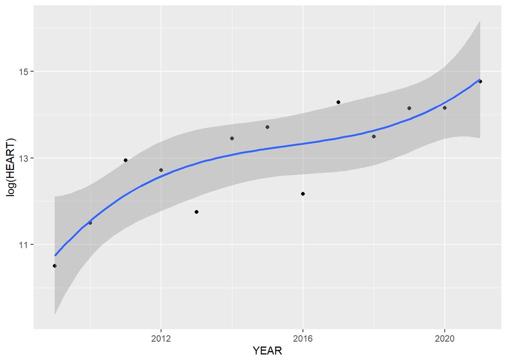

```r
# 6-4. 아이유의 성장은 계속될까?

UAENA_GRAPH <- UAENA %>% # 6-3 분석 결과를
  ggplot(aes(x = YEAR, y = log(HEART))) + # 그래프로 나타내는데
  geom_point() + # 점을 찍고
  geom_smooth(formula = y ~ poly(x, 3), method = 'lm') # 3차 회귀적합도 덧붙임

UAENA_GRAPH # 라일락 대박, 다음 앨범도 기대
```

- `aes`는 aesthetic, 그래프 변수 및 visual에 관해 전역적으로 설정.
- `log()` 함수는 자연로그가 default.
- `ggplot` 함수, 요소는 `+`로 연결.